# Lab 8

Christian Miller

2024-03-29

# Lab 8 Tasks

## Task 1

```r
setwd("C:/Users/cmill/OneDrive/Desktop/Applied Stats/Labs/Lab 8")
getwd()
```

```
## [1] "C:/Users/cmill/OneDrive/Desktop/Applied Stats/Labs/Lab 8"
```

## Task 2

```r
sample = runif(n = 10, min = 0, max = 5)
sample
```

```
##  [1] 4.8194741 4.0183423 2.2854580 3.4987153 0.9941147 0.6883278 4.3169237
##  [8] 0.9472565 4.4656872 3.6340302
```

Population mean and variance for uniform distribution where a = 0, b = 5 :

```r
mu = (0 + 5)/2
mu
```

```
## [1] 2.5
```

```r
sigmasq = (5 - 0)^2/12
sigmasq
```

```
## [1] 2.083333
```

Mean and variance from sample:

```r
xbar = mean(sample)
xbar
```

```
## [1] 2.966833
```

```r
s_squared = var(sample)
s_squared
```

```
## [1] 2.551275
```

Though some variability, the sample mean and variance are similar to the population parameters mu and sigma^2. However, with a larger sample size, the variability between the sample statistics and population parameters would lessen, according to the Central Limit Theorem.

From what we are given, we can deduce that $E(\bar{Y}) = E(Y_i) = \mu = \frac{a+b}{2}$, $E(T) = nE(Y_i) = n\mu = n\frac{a+b}{2}$,

$$V(\bar{Y}) = \frac{1}{n} V(Y_i) = \frac{1}{n} \sigma^2 =
\frac{(b-a)^2}{12n},$$
and
$$V(T) = nV(Y_i) = n\sigma^2 = n\frac{(b-a)^2}{12}.$$

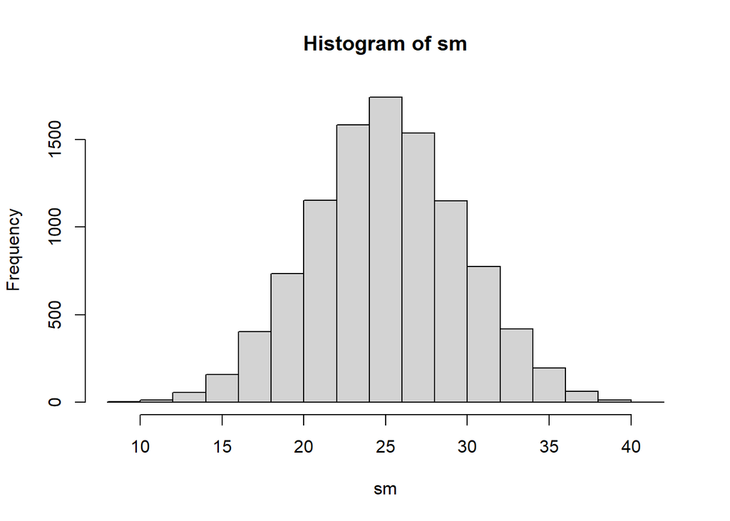

```r
myclt=function(n,iter){
y=runif(n*iter, 0, 5) # (A)
data=matrix(y,nr=n,nc=iter,byrow=TRUE) # (B)
sm=apply(data,2,sum) # (C)
hist(sm)
sm
}
w=myclt(n=10,iter=10000) # (D)
```

```r
w=myclt(n=10,iter=10000)
```

[figure not shown]

```r
mean(w)
```

```
## [1] 25.04488
```

```r
var(w)
```

```
## [1] 20.72022
```

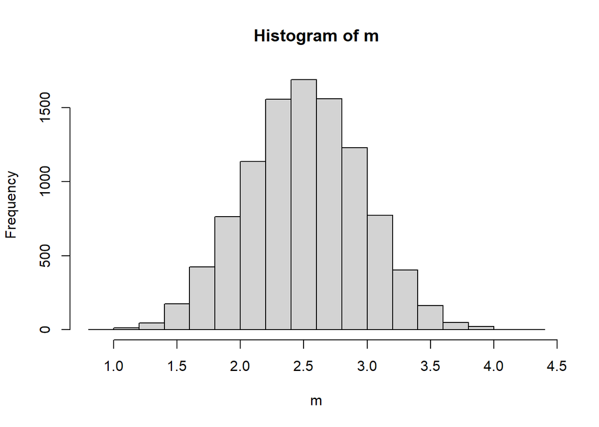

```r
myclt.mean = function(n,iter){

  y = runif(n*iter, 0, 5) # (A)

  data = matrix(y,nr=n,nc=iter,byrow=TRUE) # (B)

  m = apply(data,2,mean) # (C)

  hist(m)

  m
}

w = myclt.mean(n=10,iter=10000) # (D)
```

```r
mean(w)
```

```
## [1] 2.503145
```

```r
var(w)
```

```
## [1] 0.2089703
```

## Task 3

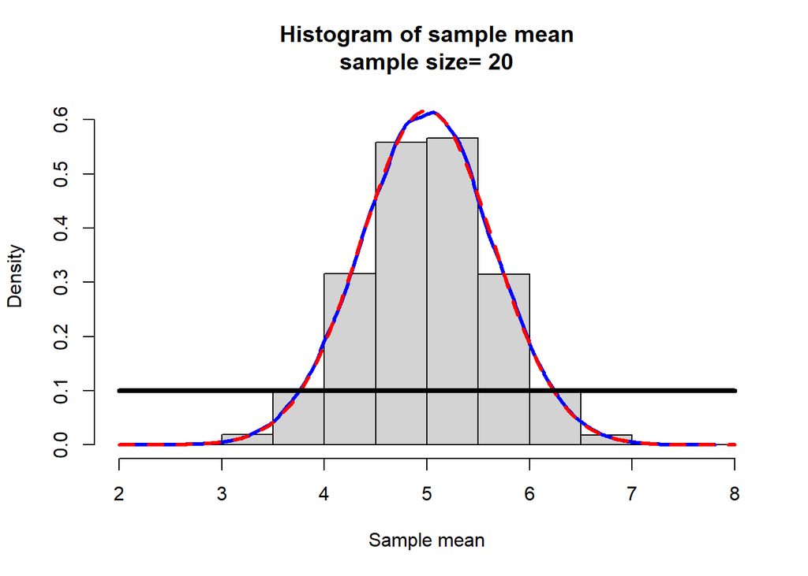

```r
mycltu=function(n,iter,a=0,b=10){
## r-random sample from the uniform
y=runif(n*iter,a,b)
## Place these numbers into a matrix
## The columns will correspond to the iteration and the rows will equal the sample size n
data=matrix(y,nr=n,nc=iter,byrow=TRUE)
## apply the function mean to the columns (2) of the matrix
## these are placed in a vector w
w=apply(data,2,mean)
## We will make a histogram of the values in w
## How high should we make y axis?
## All the values used to make a histogram are placed in param (nothing is plotted yet)
param=hist(w,plot=FALSE)
## Since the histogram will be a density plot we will find the max density

ymax=max(param$density)
## To be on the safe side we will add 10% more to this
ymax=1.1*ymax
## Now we can make the histogram
hist(w,freq=FALSE,  ylim=c(0,ymax), main=paste("Histogram of sample mean",
"\n", "sample size= ",n,sep=""),xlab="Sample mean")
## add a density curve made from the sample distribution
lines(density(w),col="Blue",lwd=3) # add a density plot
## Add a theoretical normal curve
curve(dnorm(x,mean=(a+b)/2,sd=(b-a)/(sqrt(12*n))),add=TRUE,col="Red",lty=2,lwd=3) # add a theoretical curve
## Add the density from which the samples were taken
curve(dunif(x,a,b),add=TRUE,lwd=4)

}
mycltu(n=20,iter=100000)
```

The `apply(data,2,mean)` part within `mycltu()` uses 2 for the `MARGIN` argument in `apply()` to indicate that the mean will be calculated using the columns of the matrix “data”.

`sd` takes the formula as shown in the `mycltu()` function because we know that the variance of a uniform distribution is given by $\sigma_{Y}^2 = \frac{(b-a)^2}{12}$, which tells us that $\sigma_{Y} = \frac{b-a}{\sqrt{12}}$. Because
$$V(\bar{Y}) = \frac{1}{n} V(Y), \text{ we can also
say that } \sigma_{\bar{Y}} = \frac{b-a}{\sqrt{12n}}.$$

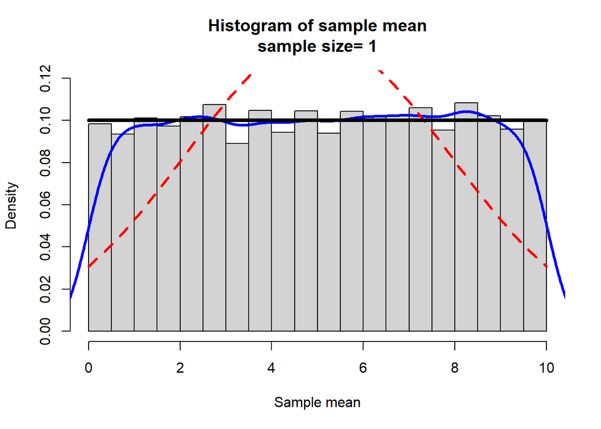

```r
mycltu(n = 1, iter = 10000, a = 0, b = 10)
```

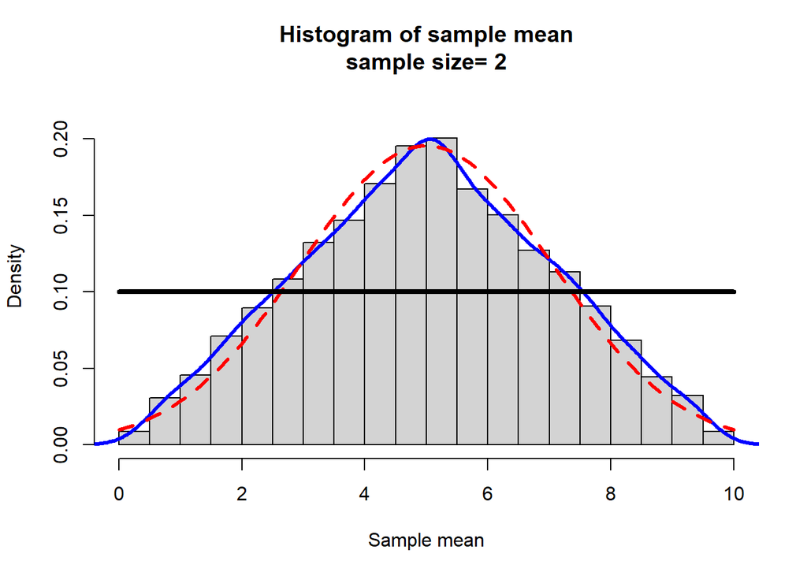

```r
mycltu(n = 2, iter = 10000, a = 0, b = 10)
```

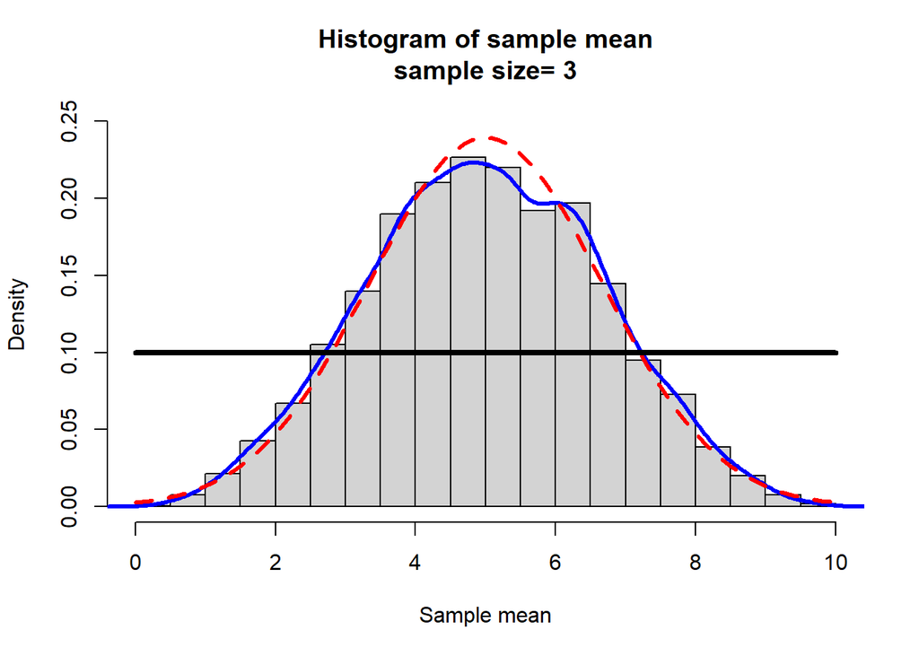

```r
mycltu(n = 3, iter = 10000, a = 0, b = 10)
```

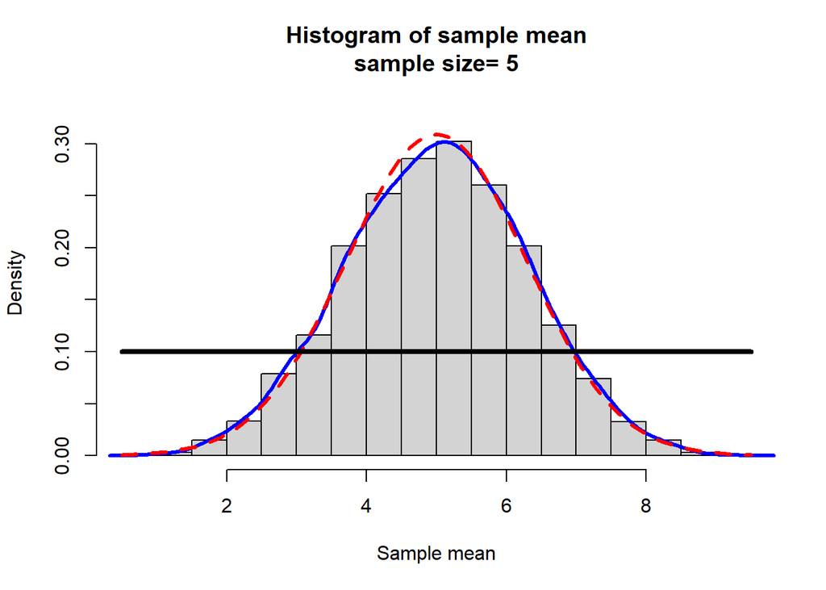

```r
mycltu(n = 5, iter = 10000, a = 0, b = 10)
```

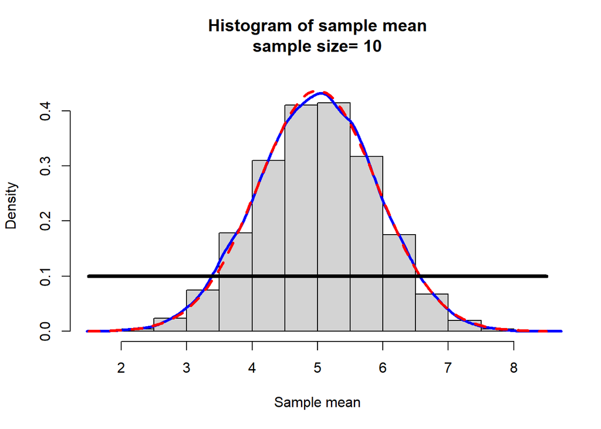

```r
mycltu(n = 10, iter = 10000, a = 0, b = 10)
```

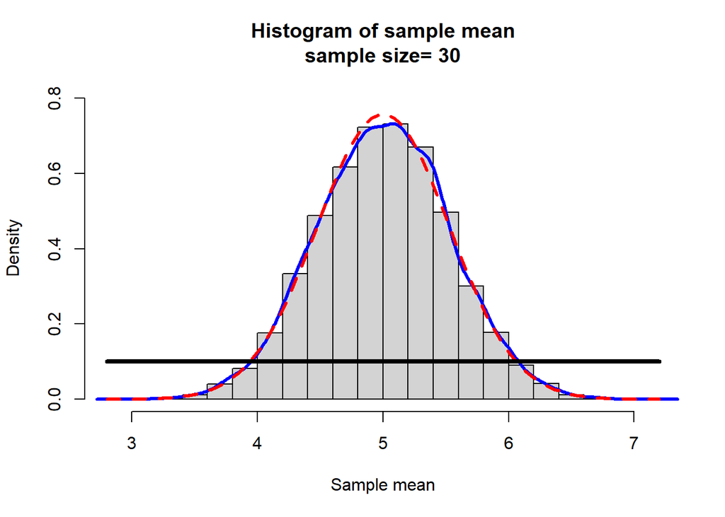

```r
mycltu(n = 30, iter = 10000, a = 0, b = 10)
```

The plots above demonstrate the properties of Central Limit Theorem, showing how the distribution converges to normal as the sample size increases. At n=30, the observed density, displayed conveniently with the blue curve, almost perfectly overlaps with the theoretical density, the dashed red curve.

## Task 4

```r
mycltb=function(n,iter,p=0.5,...){

## r-random sample from the Binomial
y=rbinom(n*iter,size=n,prob=p)
## Place these numbers into a matrix
## The columns will correspond to the iteration and the rows will equal the sample size n
data=matrix(y,nr=n,nc=iter,byrow=TRUE)
## apply the function mean to the columns (2) of the matrix
## these are placed in a vector w
w=apply(data,2,mean)
## We will make a histogram of the values in w
## How high should we make y axis?
## All the values used to make a histogram are placed in param (nothing is plotted yet)
param=hist(w,plot=FALSE)
## Since the histogram will be a density plot we will find the max density

ymax=max(param$density)
## To be on the safe side we will add 10% more to this
ymax=1.1*ymax

## Now we can make the histogram
## freq=FALSE means take a density
hist(w,freq=FALSE,  ylim=c(0,ymax),
main=paste("Histogram of sample mean","\n", "sample size= ",n,sep=""),
xlab="Sample mean",...)
## add a density curve made from the sample distribution
#lines(density(w),col="Blue",lwd=3) # add a density plot
## Add a theoretical normal curve
curve(dnorm(x,mean=n*p,sd=sqrt(p*(1-p))),add=TRUE,col="Red",lty=2,lwd=3)

}
```

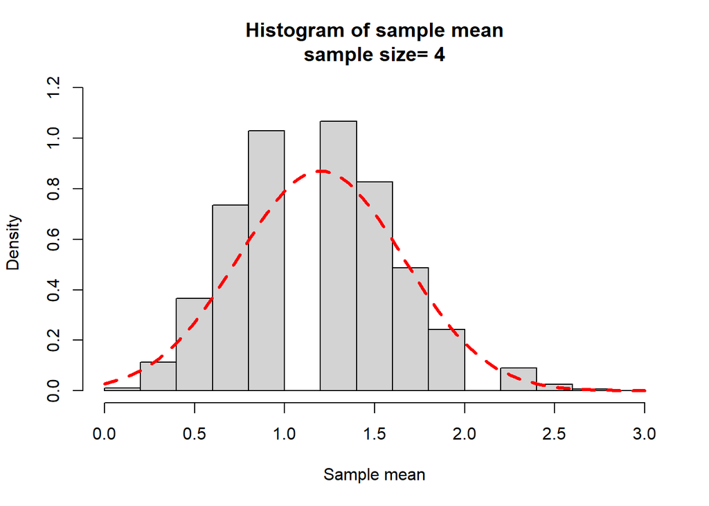

```r
mycltb(n = 4, iter = 10000, p = 0.3)
```

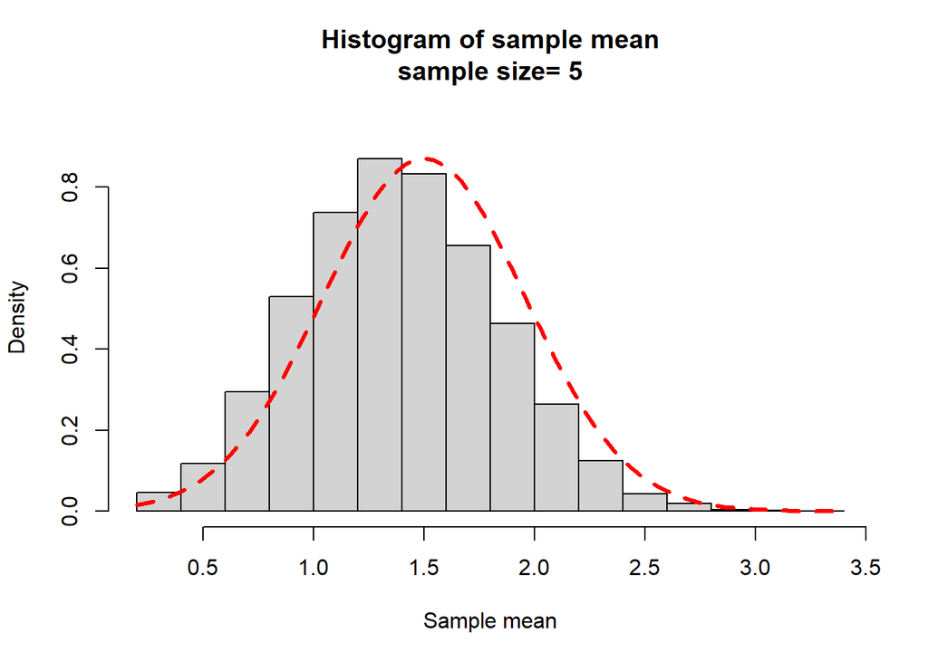

```r
mycltb(n = 5, iter = 10000, p = 0.3)
```

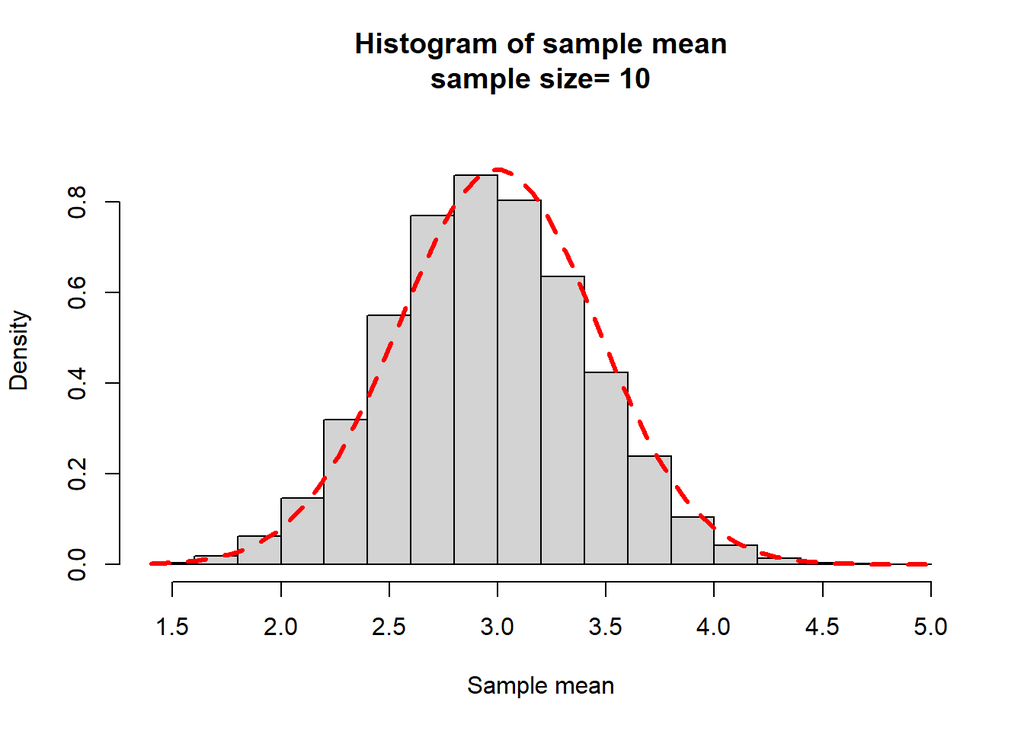

```r
mycltb(n = 10, iter = 10000, p = 0.3)
```

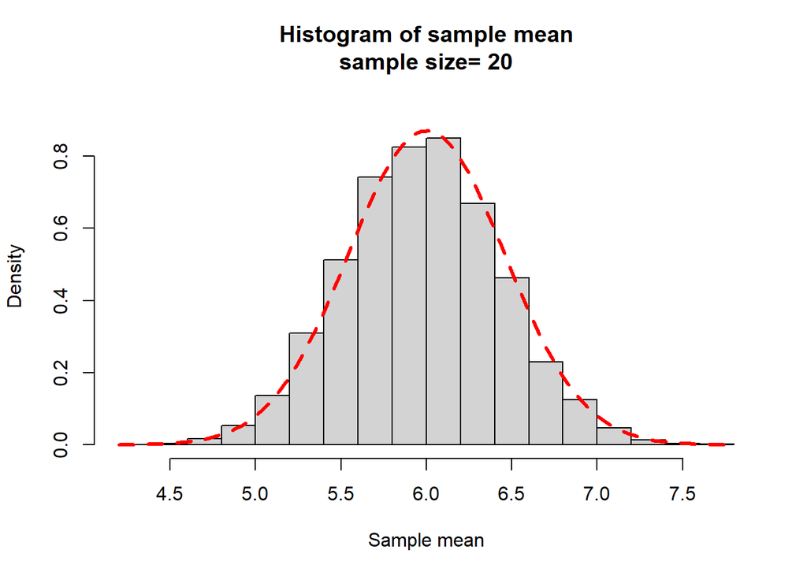

```r
mycltb(n = 20, iter = 10000, p = 0.3)
```

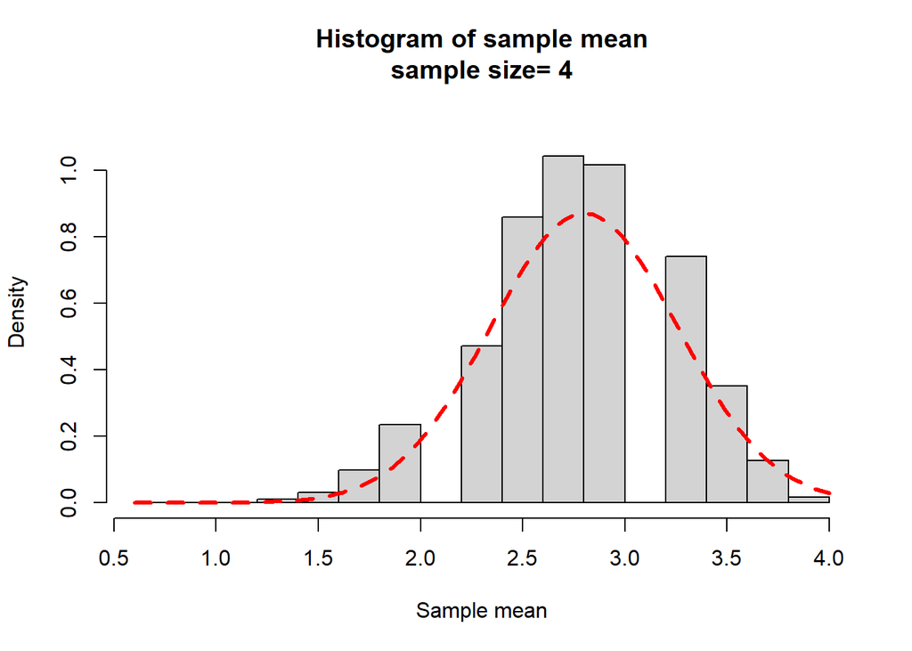

```r
mycltb(n = 4, iter = 10000, p = 0.7)
```

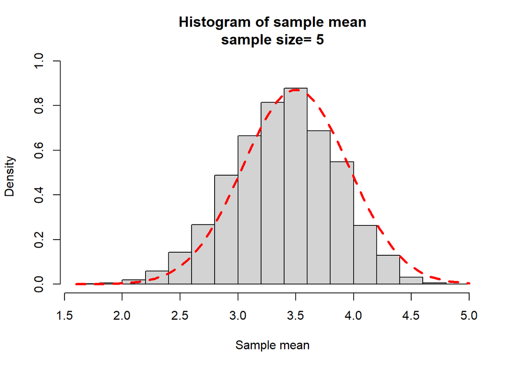

```r
mycltb(n = 5, iter = 10000, p = 0.7)
```

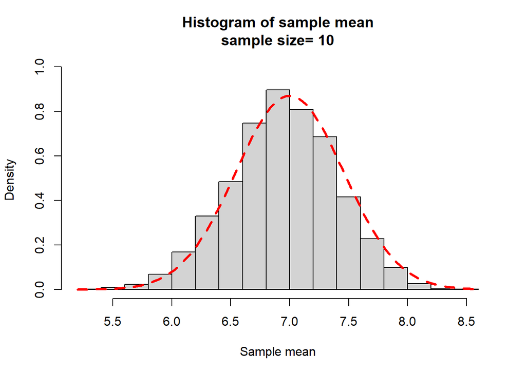

```r
mycltb(n = 10, iter = 10000, p = 0.7)
```

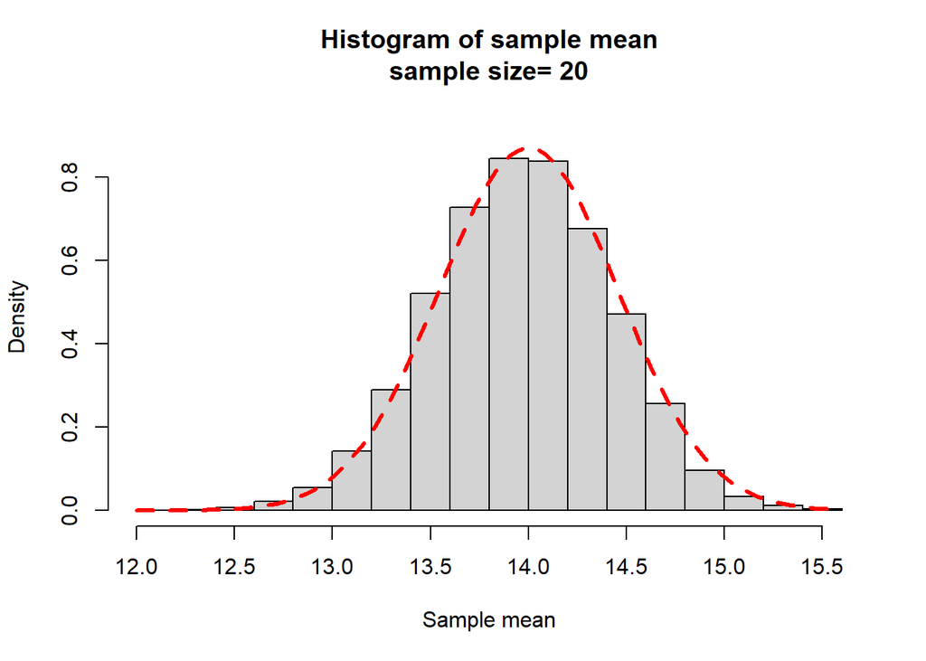

```r
mycltb(n = 20, iter = 10000, p = 0.7)
```

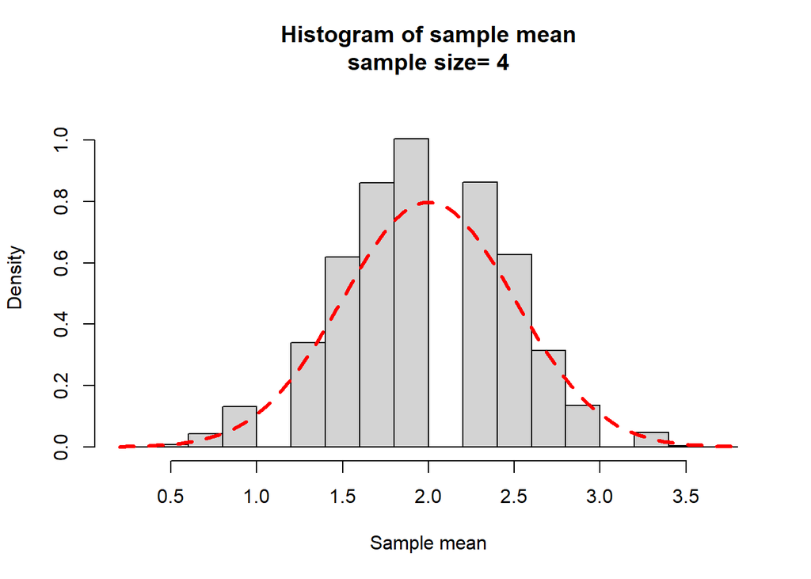

```r
mycltb(n = 4, iter = 10000, p = 0.5)
```

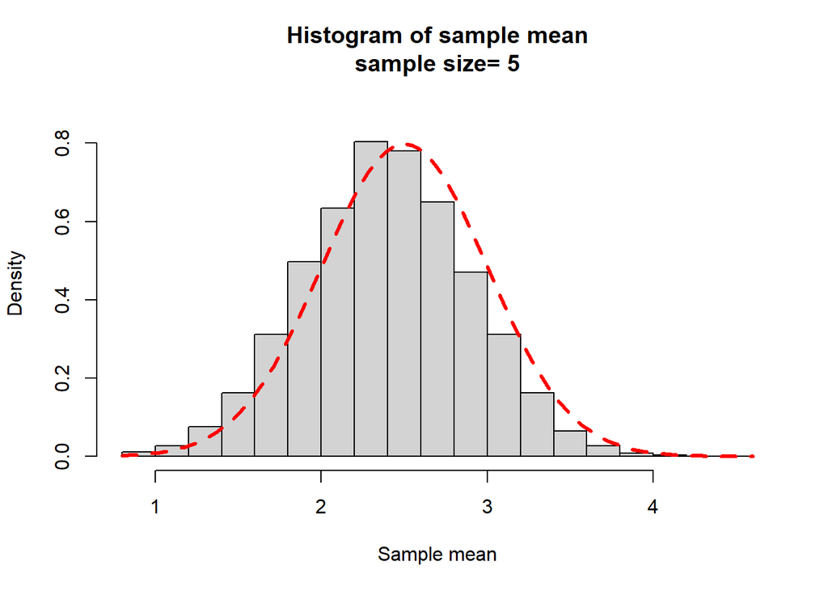

```r
mycltb(n = 5, iter = 10000, p = 0.5)
```

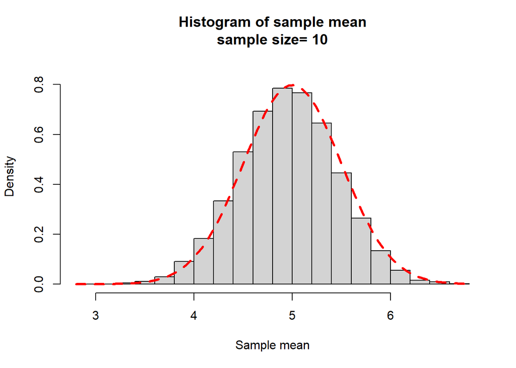

```r
mycltb(n = 10, iter = 10000, p = 0.5)
```

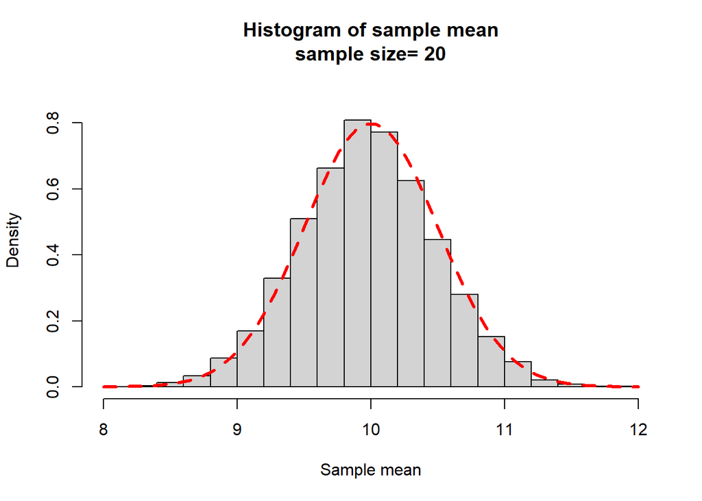

```r
mycltb(n = 20, iter = 10000, p = 0.5)
```

Like the uniform distribution case in Task 2, making samples from a binomial distribution shows the effect of the Central Limit Theorem. In each case of p=0.3, p=0.7, p=0.5, the distribution more closely resembles a normal distribution as the sample size increases. However, there is still some variability between the observed densities and the theoretical density at a sample size of n=20.

## Task 5

```r
mycltp=function(n,iter,lambda=10,...){

## r-random sample from the Poisson
y=rpois(n*iter,lambda=lambda)
## Place these numbers into a matrix
## The columns will correspond to the iteration and the rows will equal the sample size n
data=matrix(y,nr=n,nc=iter,byrow=TRUE)
## apply the function mean to the columns (2) of the matrix
## these are placed in a vector w
w=apply(data,2,mean)
## We will make a histogram of the values in w
## How high should we make y axis?
## All the values used to make a histogram are placed in param (nothing is plotted yet)
param=hist(w,plot=FALSE)
## Since the histogram will be a density plot we will find the max density

ymax=max(param$density)
## To be on the safe side we will add 10% more to this
ymax=1.1*ymax

## Make a suitable layout for graphing
layout(matrix(c(1,1,2,3),nr=2,nc=2, byrow=TRUE))

## Now we can make the histogram
hist(w,freq=FALSE,  ylim=c(0,ymax), col=rainbow(max(w)),
main=paste("Histogram of sample mean","\n", "sample size= ",n," iter=",iter," lambda=",lambda,sep=""),
xlab="Sample mean",...)
## add a density curve made from the sample distribution
#lines(density(w),col="Blue",lwd=3) # add a density plot
## Add a theoretical normal curve
curve(dnorm(x,mean=lambda,sd=sqrt(lambda/n)),add=TRUE,col="Red",lty=2,lwd=3) # add a theoretical curve

# Now make a new plot
# Since y is discrete we should use a barplot
barplot(table(y)/(n*iter),col=rainbow(max(y)), main="Barplot of sampled y", ylab ="Rel. Freq",xlab="y" )
x=0:max(y)
plot(x,dpois(x,lambda=lambda),type="h",lwd=5,col=rainbow(max(y)),
main="Probability function for Poisson", ylab="Probability",xlab="y")
}
```

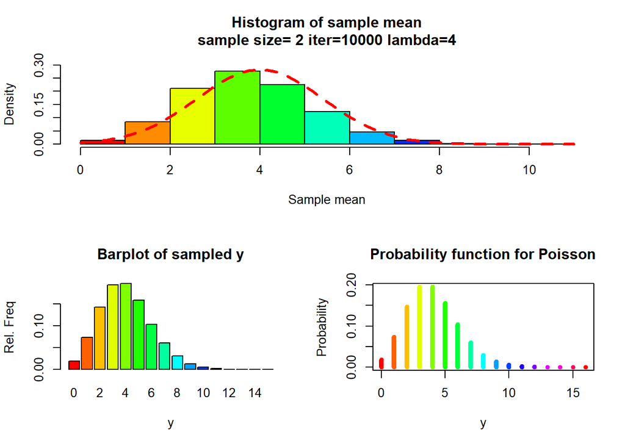

```r
mycltp(n = 2, iter = 10000, lambda = 4)
```

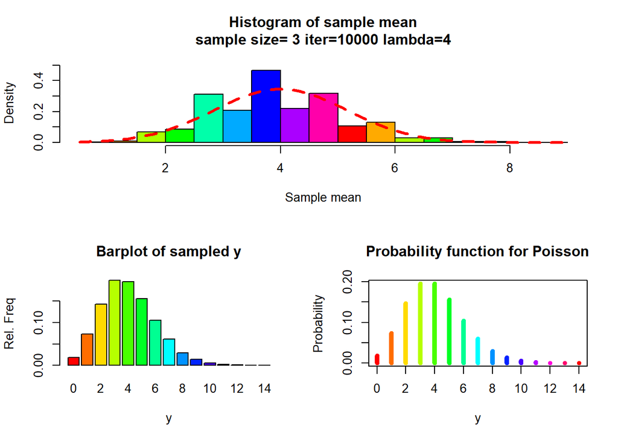

```r
mycltp(n = 3, iter = 10000, lambda = 4)
```

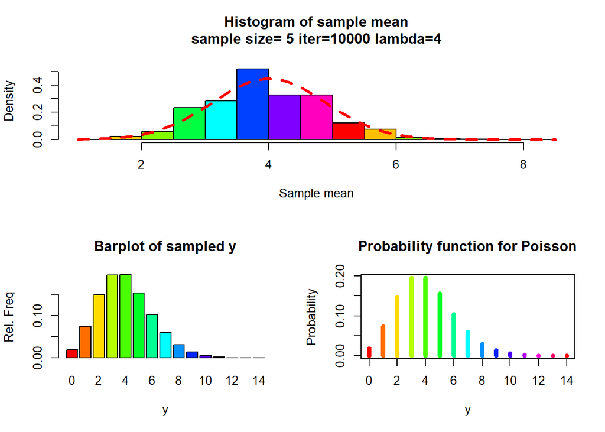

```r
mycltp(n = 5, iter = 10000, lambda = 4)
```

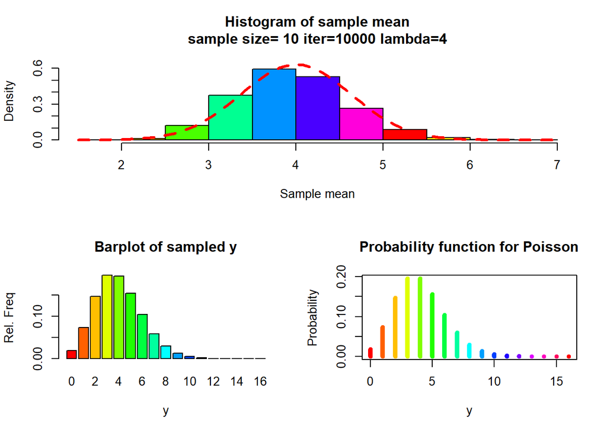

```r
mycltp(n = 10, iter = 10000, lambda = 4)
```

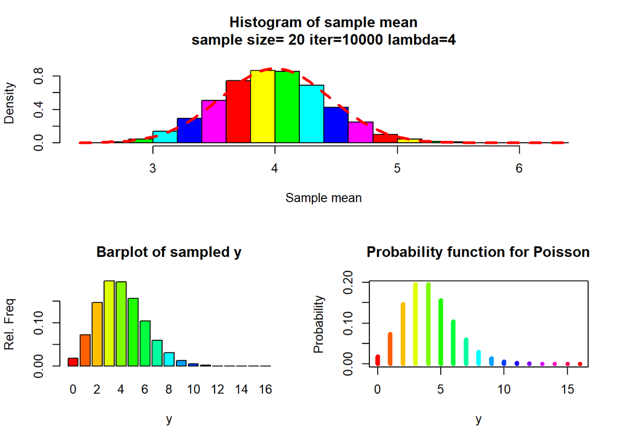

```r
mycltp(n = 20, iter = 10000, lambda = 4)
```

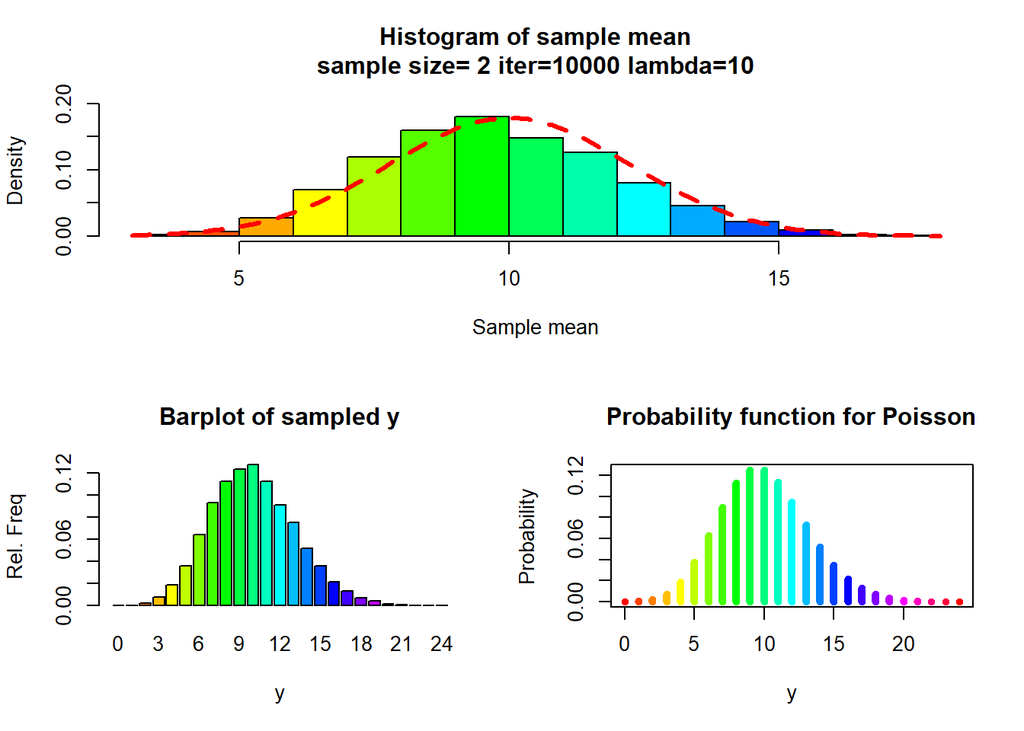

```r
mycltp(n = 2, iter = 10000, lambda = 10)
```

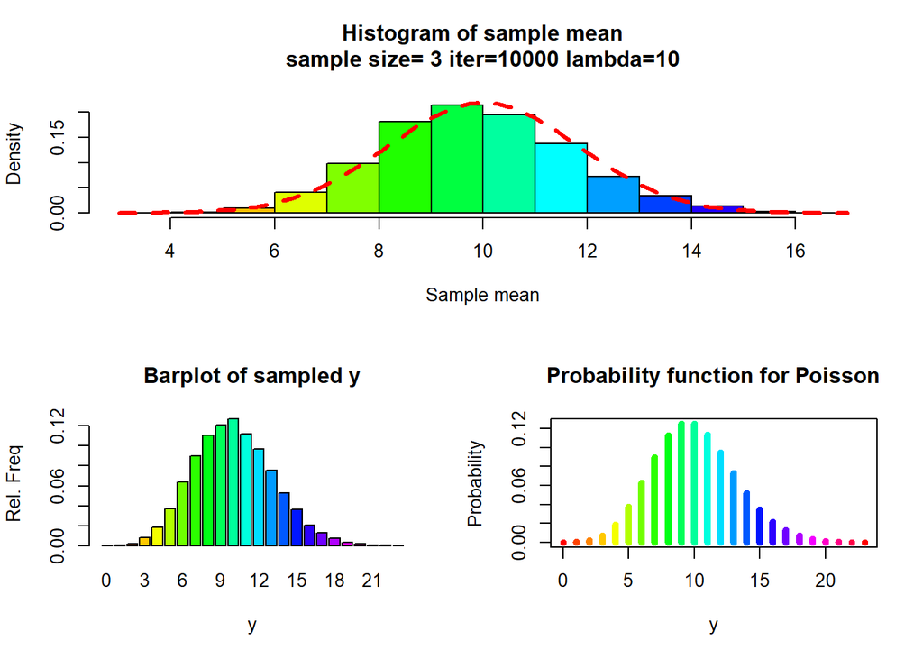

```r
mycltp(n = 3, iter = 10000, lambda = 10)
```

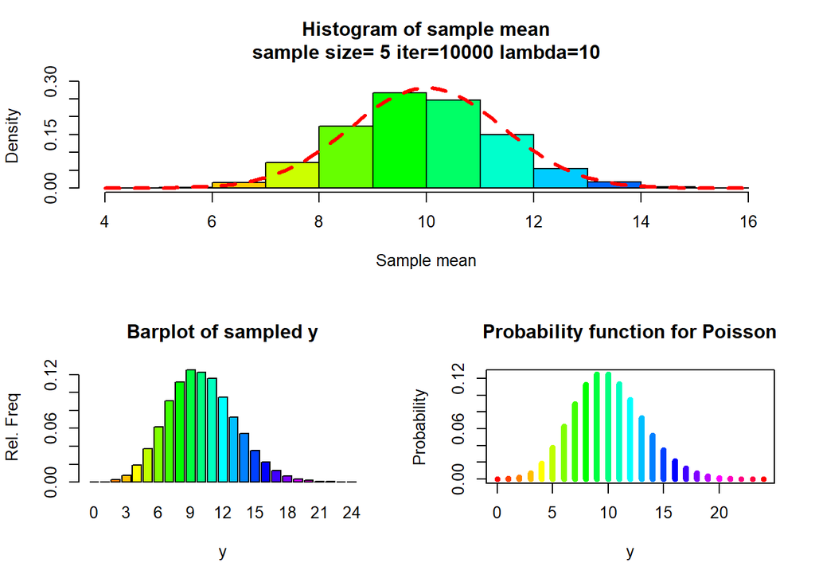

```r
mycltp(n = 5, iter = 10000, lambda = 10)
```

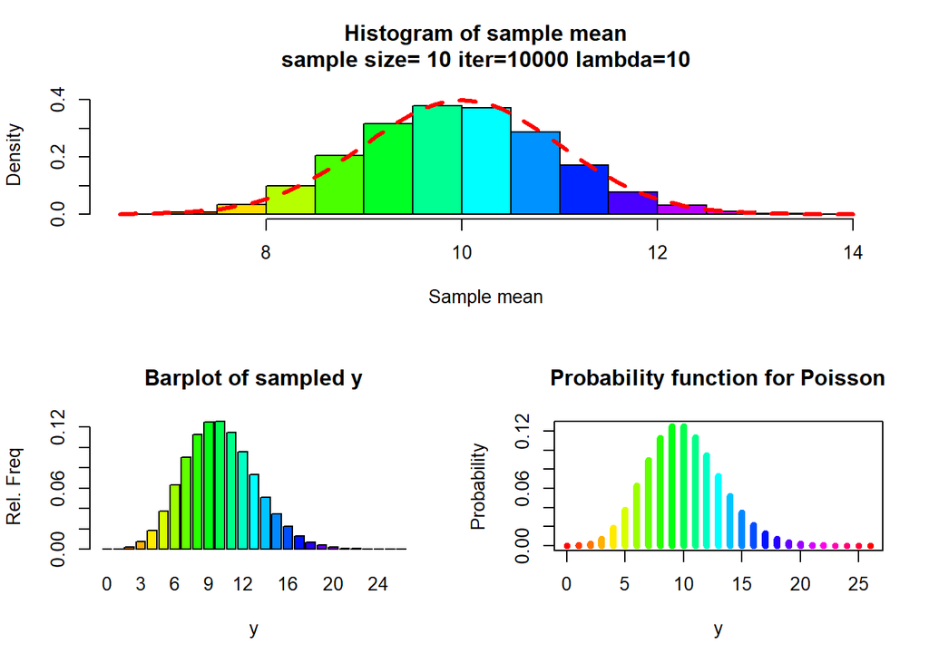

```r
mycltp(n = 10, iter = 10000, lambda = 10)
```

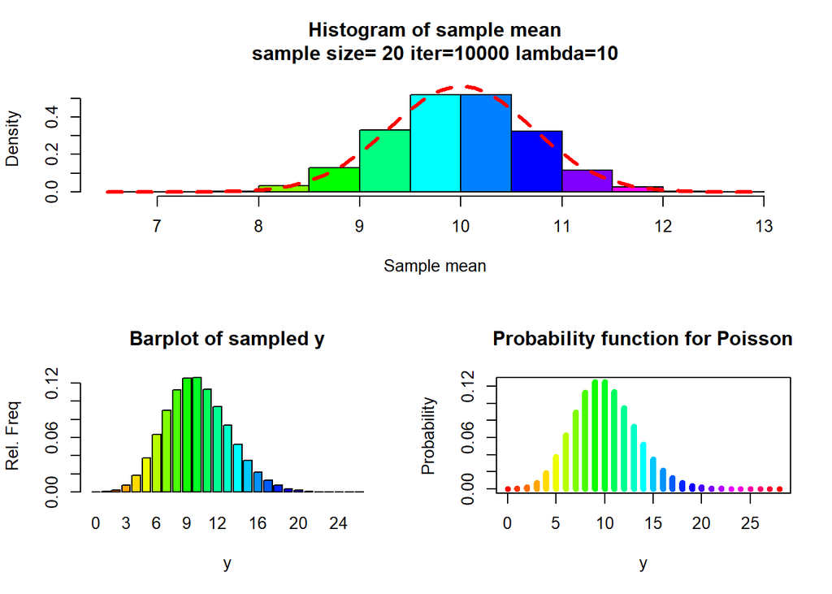

```r
mycltp(n = 20, iter = 10000, lambda = 10)
```

## Task 6

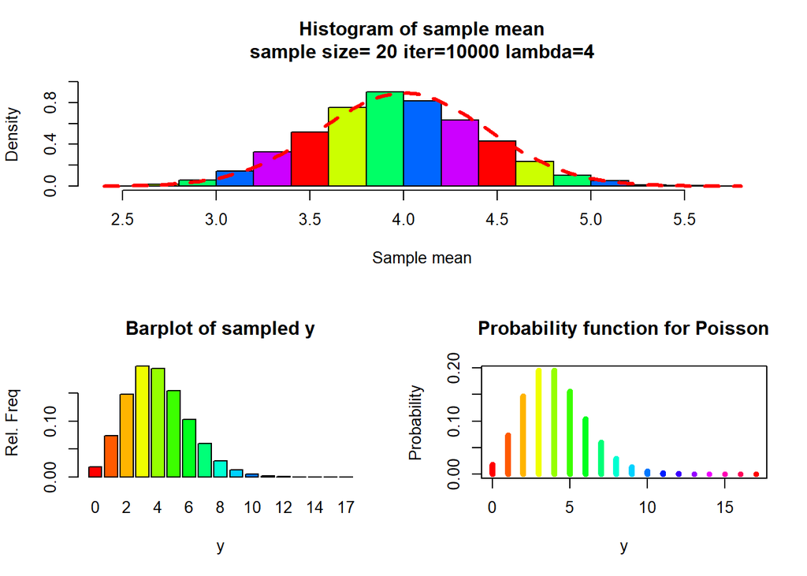

```r
MATH4753CSM24::mycltp(n = 20, iter = 10000, lambda = 4)
```